# Bike Sharing Demand

## Introduction

We have to predict the total count of bikes rented during each hour covered by the test set, using only information available prior to the rental period.

```r
require(plyr)
detach(package:plyr)
library(tidyverse)
library(lubridate)
library(broom)
library(caret)
library(scales)
library(ggcorrplot)
library(parallel)
library(doParallel)
```

```r
train.data <- tbl_df(read.csv('./Input/train.csv', stringsAsFactors = F))
test.data <- tbl_df(read.csv('./Input/test.csv', stringsAsFactors = F))
```

## Data Pre-processing, Cleaning & Feature Extraction

Adding season names.

```r
season.list <- c('spring', 'summer', 'fall', 'winter')
train.data$season.name <- train.data$season
replace_season <- function(df){
    df[['season.name']] <- plyr::mapvalues(df[['season.name']],
                                  from = c(1, 2, 3, 4),
                                  to = season.list)
    return(df)
}
train.data <- replace_season(train.data)
```

Adding weather codes as follows:  
weather 1: clear_partly_cloudy weather 2: mist_cloudy weather 3: light_snow_rain_thunderstorm weather 4: heavy_snow_rain_ice_fog_thunderstorm

```r
weather.list <- c('clear_partly_cloudy', 'mist_cloudy',
                  'light_snow_rain_thunderstorm',
                  'heavy_snow_rain_ice_fog_thunderstorm')
train.data$weather.type <- train.data$weather
replace_weather <- function(df){
    df[['weather.type']] <- plyr::mapvalues(df[['weather.type']],
                                  from = c(1, 2, 3, 4),
                                  to = weather.list)

    return(df)
}
train.data <- replace_weather(train.data)
```

Splitting datetime into year, month, day_num, day_name, hour

```r
train.data <- train.data %>%
    mutate(date.year = 0, date.month = '', month.day = 0,
           week.day = '', day.hour = 0)
split_date <- function(df){
    df[['date.year']] = year(df[['datetime']])
    df[['date.month']] = month(df[['datetime']])
    df[['date.month.name']] = month(df[['datetime']], label = T)
    df[['month.day']] = day(df[['datetime']])
    df[['week.day']] = wday(df[['datetime']])
    df[['week.day.name']] = wday(df[['datetime']], label = T)
    df[['day.hour']] = hour(df[['datetime']])

    return(df)
}
train.data <- split_date(train.data)
```

Adding new column, temp.div <- temp / atemp

```r
train.data <- train.data %>%
    mutate(temp.div = temp / atemp)
```

Adding new column, day.type – 1.holiday, 2.working day or 3.weekend

```r
train.data <- train.data %>%
    mutate(day.type = NA, day.type.name = NA)
day_type <- function(df){
    df[['day.type']] <- ifelse(df[['holiday']] == 1, 1,
                               ifelse(df[['workingday']] == 1, 2,
                                      3))
    df[['day.type.name']] <- ifelse(df[['day.type']] == 1, 'Holiday',
                               ifelse(df[['day.type']] == 2, 'Workingday',
                                      'Weekend'))
    return(df)
}
train.data <- day_type(train.data) %>% select(-holiday, -workingday)
```

Now lets check the data again

```r
summary(train.data)
```

```
   datetime             season         weather           temp
 Length:10886       Min.   :1.000   Min.   :1.000   Min.   : 0.82
 Class :character   1st Qu.:2.000   1st Qu.:1.000   1st Qu.:13.94
 Mode  :character   Median :3.000   Median :1.000   Median :20.50
                    Mean   :2.507   Mean   :1.418   Mean   :20.23
                    3rd Qu.:4.000   3rd Qu.:2.000   3rd Qu.:26.24
                    Max.   :4.000   Max.   :4.000   Max.   :41.00

     atemp          humidity        windspeed          casual
 Min.   : 0.76   Min.   :  0.00   Min.   : 0.000   Min.   :  0.00
 1st Qu.:16.66   1st Qu.: 47.00   1st Qu.: 7.002   1st Qu.:  4.00
 Median :24.24   Median : 62.00   Median :12.998   Median : 17.00
 Mean   :23.66   Mean   : 61.89   Mean   :12.799   Mean   : 36.02
 3rd Qu.:31.06   3rd Qu.: 77.00   3rd Qu.:16.998   3rd Qu.: 49.00
 Max.   :45.45   Max.   :100.00   Max.   :56.997   Max.   :367.00

   registered        count       season.name        weather.type
 Min.   :  0.0   Min.   :  1.0   Length:10886       Length:10886
 1st Qu.: 36.0   1st Qu.: 42.0   Class :character   Class :character
 Median :118.0   Median :145.0   Mode  :character   Mode  :character
 Mean   :155.6   Mean   :191.6
 3rd Qu.:222.0   3rd Qu.:284.0
 Max.   :886.0   Max.   :977.0

   date.year      date.month       month.day         week.day
 Min.   :2011   Min.   : 1.000   Min.   : 1.000   Min.   :1.000
 1st Qu.:2011   1st Qu.: 4.000   1st Qu.: 5.000   1st Qu.:2.000
 Median :2012   Median : 7.000   Median :10.000   Median :4.000
 Mean   :2012   Mean   : 6.521   Mean   : 9.993   Mean   :3.999
 3rd Qu.:2012   3rd Qu.:10.000   3rd Qu.:15.000   3rd Qu.:6.000
 Max.   :2012   Max.   :12.000   Max.   :19.000   Max.   :7.000

    day.hour     date.month.name week.day.name    temp.div         day.type
 Min.   : 0.00   May    : 912    Sun  :1579    Min.   :0.2706   Min.   :1.000
 1st Qu.: 6.00   Jun    : 912    Mon  :1551    1st Qu.:0.8119   1st Qu.:2.000
 Median :12.00   Jul    : 912    Tues :1539    Median :0.8528   Median :2.000
 Mean   :11.54   Aug    : 912    Wed  :1551    Mean   :0.8496   Mean   :2.262
 3rd Qu.:18.00   Dec    : 912    Thurs:1553    3rd Qu.:0.8762   3rd Qu.:3.000
 Max.   :23.00   Oct    : 911    Fri  :1529    Max.   :2.9092   Max.   :3.000
                 (Other):5415    Sat  :1584
 day.type.name
 Length:10886
 Class :character
 Mode  :character
```

## Data Exploration

First lets check the proportion of casual to registered users

```r
train.data %>% mutate(casual.count = sum(casual),
                      registered.count = sum(registered)) %>%
    select(casual.count, registered.count) %>%
    distinct() %>%
    gather(key = user.type, value = user.count,
           casual.count:registered.count) %>%
    mutate(user.prop = user.count / sum(user.count))
```

| user.type | user.count | user.prop |
| --- | --- | --- |
| casual.count | 392135 | 0.1880314 |
| registered.count | 1693341 | 0.8119686 |

```r
NA
```

### No. of Users by Season & Weather

Lets check the effect of seasons and weather on the users

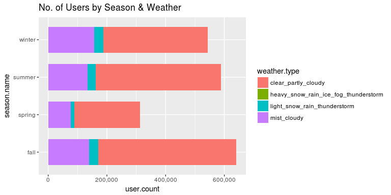

```r
train.data %>%
    select(season.name, weather.type, count) %>%
    group_by(season.name, weather.type) %>%
    mutate(user.count = sum(count)) %>%
    distinct(season.name, weather.type,user.count) %>%
    ggplot(mapping = aes(season.name, user.count, fill = weather.type)) +
    geom_bar(stat = 'identity', width = 0.7) +
    scale_y_continuous(labels = comma) +
    coord_flip() +
    ggtitle('No. of Users by Season & Weather')
```

It seems less people ride bicycles during Spring season than other seasons.

Most people ride during good weather (Clear, Partly Cloudy). Only the most dedicated ride in bad weather (Thunderstorm, Light snow or Rain).

### Usage pattern over Days of Week & Hours of Day

Lets check user count over days of week

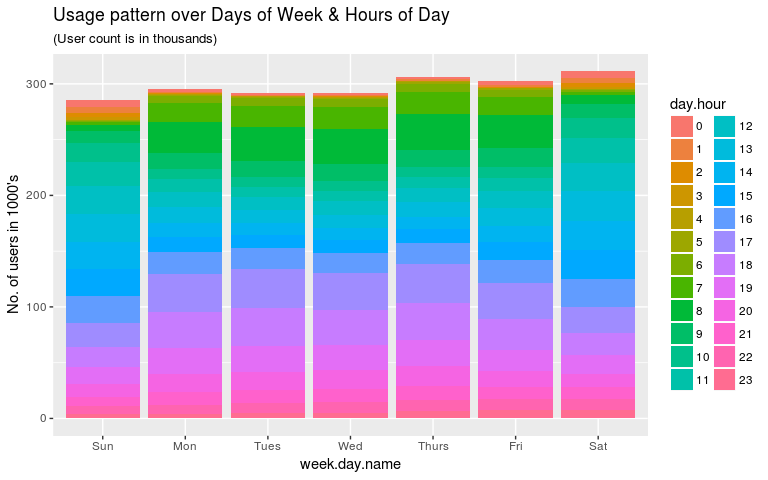

```r
train.data %>%
    mutate(week.day.name = as.factor(week.day.name),
           day.hour = as.factor(day.hour)) %>%
    select(week.day.name, day.hour, count) %>%
    group_by(week.day.name, day.hour) %>%
    mutate(user.count = sum(count)) %>%
    distinct(week.day.name, day.hour, user.count) %>%
    ggplot(mapping = aes(x = week.day.name, y = user.count/1000,
                         fill = day.hour)) +
    geom_bar(stat = 'identity') +
    ylab('No. of users in 1000\'s') +
    ggtitle(label = 'Usage pattern over Days of Week & Hours of Day',
            subtitle = '(User count is in thousands)')
```

The overall user count remains almost same for all 7 day of the week. But clear patterns can be seen for hourly usage on weekdays vs weekends.

On weekends the 11 AM to 5 PM time has most traffic.

### No. of Users based on Hour of Day over the Years

Lets check what time of the day most users ride.

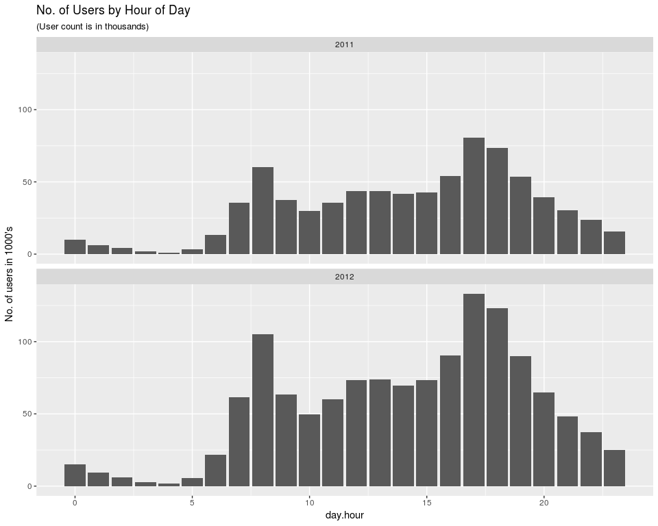

```r
train.data %>%
    select(day.hour, date.year, count) %>%
    group_by(day.hour, date.year) %>%
    mutate(user.count = sum(count)) %>%
    distinct(day.hour, date.year, user.count) %>%
    ggplot(mapping = aes(x = day.hour, y = user.count/1000)) +
    geom_bar(stat = 'identity') +
    facet_wrap(~ date.year, nrow = 2) +
    ylab('No. of users in 1000\'s') +
    ggtitle(label = 'No. of Users by Hour of Day',
            subtitle = '(User count is in thousands)')
```

As expected, most users ride between 6 AM to 11 PM. The bicycle use peaks at 8 AM and between 4 PM to 7 PM.

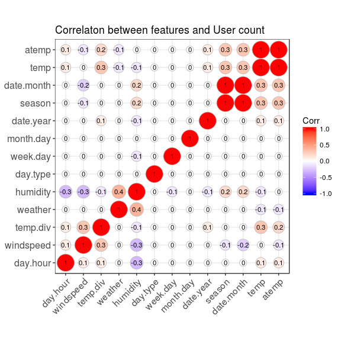

```r
train.data %>%
    select(c(2:7, 13:17, 20:21)) %>%
    distinct() %>% cor() %>% round(digits = 1) %>%
    ggcorrplot(method = 'circle',
               type = 'full', hc.order = T, lab = T, lab_size = 3,
               ggtheme = theme_bw,
               title = 'Correlaton between features and User count')
```

## Model Training, Prediction & Evaluation - 1

We will use Linear Model, Decision Tree(RPart) & Random Forest to train our models.

First we will Configure parallel processing

```r
ncluster <- makeCluster(detectCores() - 1)
registerDoParallel(ncluster)
```

Splitting training and testing datasets

```r
set.seed(777)
sample.train.data <- sample_n(train.data, size = 2000)

inTraining <- createDataPartition(y = sample.train.data$count,
                                  p = 0.75, list = F)
training <- sample.train.data[inTraining, ]
testing <- sample.train.data[-inTraining, ]
```

```r
# set.seed(777)
#
# inTraining <- createDataPartition(y = train.data$count,
#                                   p = 0.75, list = F)
# training <- train.data[inTraining, ]
# testing <- train.data[-inTraining, ]
```

Choosing Features to use in model

```r
feature.list <- c(2:7, 13:17, 20:21)
```

Setting train control and grid parameters

```r
tr.ctrl <- trainControl(method = 'repeatedcv', number = 5, repeats = 5,
                        verboseIter = T, allowParallel = T)
grid.rf <- expand.grid(.mtry = c(2, 4, 8, 13))
```

Training models

```r
set.seed(777)
fit.lm.casual <- train(x = training[feature.list], y = training$casual,
                       method = 'lm', metric = 'RMSE', trControl = tr.ctrl)
set.seed(777)
fit.lm.reg <- train(x = training[feature.list], y = training$registered,
                       method = 'lm', metric = 'RMSE', trControl = tr.ctrl)
set.seed(777)
fit.lm.count <- train(x = training[feature.list], y = training$count,
                       method = 'lm', metric = 'RMSE', trControl = tr.ctrl)
```

```r
set.seed(777)
fit.rpart.casual <- train(x = training[feature.list], y = training$casual,
                          method = 'rpart', metric = 'RMSE', trControl = tr.ctrl)
set.seed(777)
fit.rpart.reg <- train(x = training[feature.list], y = training$registered,
                          method = 'rpart', metric = 'RMSE', trControl = tr.ctrl)
set.seed(777)
fit.rpart.count <- train(x = training[feature.list], y = training$count,
                          method = 'rpart', metric = 'RMSE', trControl = tr.ctrl)
```

```r
set.seed(777)
fit.rf.casual <- train(x = training[feature.list], y = training$casual,
                method = 'rf', metric = 'RMSE', importance = T,
                trControl = tr.ctrl, tuneGrid = grid.rf)
```

[output not shown]

[output not shown]

Evaluating the models

```r
resamps <- resamples(list(LM.cas = fit.lm.casual,
                          LM.reg = fit.lm.reg,
                          LM.count = fit.lm.count,
                          RPART.cas = fit.rpart.casual,
                          RPART.reg = fit.rpart.reg,
                          RPART.count = fit.rpart.count,
                          RF.cas = fit.rf.casual,
                          RF.reg = fit.rf.reg,
                          RF.count = fit.rf.count))
summary(resamps)
```

```
Call:
summary.resamples(object = resamps)

Models: LM.cas, LM.reg, LM.count, RPART.cas, RPART.reg, RPART.count, RF.cas, RF.reg, RF.count
Number of resamples: 25

RMSE
                 Min.   1st Qu.    Median      Mean   3rd Qu.      Max. NA's
LM.cas       32.22807  35.95885  37.85431  37.22181  38.61334  40.95296    0
LM.reg      104.99454 113.58351 116.22236 117.95846 122.06675 130.27346    0
LM.count    126.00584 131.77975 134.85971 135.18125 138.42475 144.21012    0
RPART.cas    34.61962  36.20900  39.15939  38.95147  41.22415  43.81699    0
RPART.reg    98.20691 106.83518 112.04193 111.76319 116.44008 127.75602    0
RPART.count 121.89918 129.70752 133.79737 133.66237 137.88370 142.73604    0
RF.cas       15.99220  17.93296  18.79749  19.24214  20.37183  21.99005    0
RF.reg       44.62267  48.28364  50.31905  51.40869  55.95957  58.59132    0
RF.count     64.46793  70.64586  74.14882  74.64900  78.21535  85.21250    0

Rsquared
                 Min.   1st Qu.    Median      Mean   3rd Qu.      Max. NA's
LM.cas      0.3895336 0.4439388 0.4519886 0.4484690 0.4573795 0.4874484    0
LM.reg      0.2898759 0.3314686 0.3481814 0.3498559 0.3718990 0.4033594    0
LM.count    0.3734947 0.3987514 0.4148601 0.4138060 0.4308088 0.4655961    0
RPART.cas   0.2515774 0.3193316 0.3822543 0.3943342 0.4696074 0.5739546    0
RPART.reg   0.3354274 0.3887204 0.4060062 0.4182946 0.4564742 0.5085819    0
RPART.count 0.3481676 0.4056499 0.4291109 0.4265187 0.4423755 0.5044783    0
RF.cas      0.8038954 0.8367751 0.8543359 0.8525553 0.8691155 0.8983531    0
RF.reg      0.8396347 0.8681285 0.8867445 0.8803219 0.8938734 0.9108960    0
RF.count    0.7741893 0.8090016 0.8271351 0.8239567 0.8379938 0.8704832    0
```

Random Forest is clearly the best performer.

Variable Importance

```r
varImp(object = fit.rf.casual, scale = T)
```

```
rf variable importance

           Overall
day.type   100.000
day.hour    75.321
atemp       45.782
humidity    25.625
date.year   15.595
temp        11.034
date.month   9.421
week.day     6.969
month.day    6.039
windspeed    1.769
temp.div     1.757
season       1.040
weather      0.000
```

```r
varImp(object = fit.rf.reg, scale = T)
```

```
rf variable importance

           Overall
day.hour   100.000
date.year   45.279
day.type    37.623
date.month  18.668
atemp       12.637
temp        11.285
humidity    10.273
week.day     7.144
temp.div     4.765
season       4.048
windspeed    3.487
weather      3.310
month.day    0.000
```

```r
varImp(object = fit.rf.count, scale = T)
```

```
rf variable importance

           Overall
day.hour   100.000
date.year   39.886
day.type    27.688
atemp       15.541
humidity    15.327
date.month  14.996
temp         8.665
week.day     8.050
season       3.752
temp.div     3.561
windspeed    1.178
weather      1.165
month.day    0.000
```

De-registering parallel processing cluster

```r
stopCluster(ncluster)
registerDoSEQ()
```

Lets run the model on our testing split.

```r
predict.rf.casual <- predict(fit.rf.casual, newdata = testing[feature.list])
predict.rf.reg <- predict(fit.rf.reg, newdata = testing[feature.list])
predict.rf.count <- predict(fit.rf.count, newdata = testing[feature.list])
predict.rf.count.add <- predict.rf.casual + predict.rf.reg
```

Lets evaluate our model

```r
RMSE(pred = predict.rf.count, obs = testing$count)
```

```
[1] 75.55202
```

```r
RMSE(pred = predict.rf.count.add, obs = testing$count)
```

```
[1] 59.56385
```

## Model Training, Prediction & Evaluation - 2

This time we will remove Features having variable importance less than 5% for each model and see if it improves our models.

First we will Configure parallel processing

```r
ncluster <- makeCluster(detectCores() - 1)
registerDoParallel(ncluster)
```

Splitting training and testing datasets

```r
set.seed(777)
sample.train.data <- sample_n(train.data, size = 2000)

inTraining <- createDataPartition(y = sample.train.data$count,
                                  p = 0.75, list = F)
training <- sample.train.data[inTraining, ]
testing <- sample.train.data[-inTraining, ]
```

```r
# set.seed(777)
#
# inTraining <- createDataPartition(y = train.data$count,
#                                   p = 0.75, list = F)
# training <- train.data[inTraining, ]
# testing <- train.data[-inTraining, ]
```

Choosing Features to use in model

```r
feature.list.casual2 <- c(4:6, 13:17, 21)
feature.list.reg2 <- c(4:6, 13:14, 16:17, 21)
feature.list.count2 <- c(4:6, 13:14, 16:17, 21)
```

Setting train control and grid parameters

```r
tr.ctrl <- trainControl(method = 'repeatedcv', number = 5, repeats = 5,
                        verboseIter = T, allowParallel = T)
grid.rf <- expand.grid(.mtry = c(2, 4, 8))
```

Training model

```r
set.seed(777)
fit.rf.casual2 <- train(x = training[feature.list.casual2], y = training$casual,
                method = 'rf', metric = 'RMSE', importance = T,
                trControl = tr.ctrl, tuneGrid = grid.rf)
set.seed(777)
fit.rf.reg2 <- train(x = training[feature.list.reg2], y = training$registered,
                method = 'rf', metric = 'RMSE', importance = T,
                trControl = tr.ctrl, tuneGrid = grid.rf)
set.seed(777)
fit.rf.count2 <- train(x = training[feature.list.count2], y = training$count,
                method = 'rf', metric = 'RMSE', importance = T,
                trControl = tr.ctrl, tuneGrid = grid.rf)
```

Evaluating the model

```r
resamps <- resamples(list(RF.Casual1 = fit.rf.casual,
                          RF.Casual2 = fit.rf.casual2,
                          RF.Reg1 = fit.rf.reg,
                          RF.Reg2 = fit.rf.reg2,
                          RF.Count = fit.rf.count,
                          RF.Count2 = fit.rf.count2))
summary(resamps)
```

```
Call:
summary.resamples(object = resamps)

Models: RF.Casual1, RF.Casual2, RF.Reg1, RF.Reg2, RF.Count, RF.Count2
Number of resamples: 25

RMSE
               Min.  1st Qu.   Median     Mean  3rd Qu.     Max. NA's
RF.Casual1 15.99220 17.93296 18.79749 19.24214 20.37183 21.99005    0
RF.Casual2 15.17006 17.59973 18.69227 18.77821 20.05997 22.02664    0
RF.Reg1    44.62267 48.28364 50.31905 51.40869 55.95957 58.59132    0
RF.Reg2    42.13026 44.28133 45.73066 47.45345 51.71722 54.45530    0
RF.Count   64.46793 70.64586 74.14882 74.64900 78.21535 85.21250    0
RF.Count2  59.07926 63.63760 67.08296 67.43273 70.91496 79.05507    0

Rsquared
                Min.   1st Qu.    Median      Mean   3rd Qu.      Max. NA's
RF.Casual1 0.8038954 0.8367751 0.8543359 0.8525553 0.8691155 0.8983531    0
RF.Casual2 0.8049504 0.8442251 0.8600300 0.8591969 0.8693223 0.9080326    0
RF.Reg1    0.8396347 0.8681285 0.8867445 0.8803219 0.8938734 0.9108960    0
RF.Reg2    0.8572027 0.8874988 0.9026229 0.8966439 0.9101889 0.9171074    0
RF.Count   0.7741893 0.8090016 0.8271351 0.8239567 0.8379938 0.8704832    0
RF.Count2  0.8054646 0.8472627 0.8595764 0.8563594 0.8698405 0.8909048    0
```

By removing the weaker features, the model has improved.

Variable Importance

```r
varImp(object = fit.rf.casual2, scale = T)
```

```
rf variable importance

           Overall
day.hour   100.000
day.type    99.922
atemp       56.463
humidity    38.915
date.year   21.670
date.month  16.051
temp        14.639
month.day    7.422
week.day     0.000
```

```r
varImp(object = fit.rf.reg2, scale = T)
```

```
rf variable importance

           Overall
day.hour   100.000
date.year   40.881
day.type    33.112
date.month  18.390
atemp        6.898
humidity     6.646
temp         4.396
week.day     0.000
```

```r
varImp(object = fit.rf.count2, scale = T)
```

```
rf variable importance

            Overall
day.hour   100.0000
date.year   32.6724
day.type    23.8061
date.month   8.3480
atemp        6.9737
humidity     6.5232
temp         0.6462
week.day     0.0000
```

De-registering parallel processing cluster

```r
stopCluster(ncluster)
registerDoSEQ()
```

Lets run the model on our testing split.

```r
predict.rf.casual2 <- predict(fit.rf.casual2,
                              newdata = testing[feature.list.casual2])
predict.rf.reg2 <- predict(fit.rf.reg2,
                           newdata = testing[feature.list.reg2])
predict.rf.count2 <- predict(fit.rf.count2,
                             newdata = testing[feature.list.count2])
predict.rf.count.add2 <- predict.rf.casual2 + predict.rf.reg2
```

Lets evaluate our model

```r
RMSE(pred = predict.rf.count2, obs = testing$count)
```

```
[1] 68.20862
```

```r
RMSE(pred = predict.rf.count.add2, obs = testing$count)
```

```
[1] 56.02211
```

## Model Training, Prediction & Evaluation - 3

This time we will try tuning the models further and see if it improves our models.

First we will Configure parallel processing.

```r
# ncluster <- makeCluster(detectCores() - 1)
# registerDoParallel(ncluster)
```

Splitting training and testing datasets

```r
# set.seed(777)
#
# sample.train.data <- sample_n(train.data, size = 2000)
#
# inTraining <- createDataPartition(y = sample.train.data$count,
#                                   p = 0.75, list = F)
# training <- sample.train.data[inTraining, ]
# testing <- sample.train.data[-inTraining, ]
```

```r
# set.seed(777)
#
# inTraining <- createDataPartition(y = train.data$count,
#                                   p = 0.75, list = F)
# training <- train.data[inTraining, ]
# testing <- train.data[-inTraining, ]
```

Choosing Features to use in model

```r
# feature.list.casual3 <- c(2, 5:6, 11:15, 17)
# feature.list.reg3 <- c(2:3, 5:6, 11:12, 14:15, 17)
# feature.list.count3 <- c(2, 5:6, 11:12, 14:15, 17)
```

Setting train control and grid parameters

```r
# tr.ctrl <- trainControl(method = 'repeatedcv', number = 10, repeats = 10,
#                         verboseIter = T, allowParallel = T)
#
# grid.rf <- expand.grid(.mtry = c(5, 7, 9, 12, 14))
```

Training model

```r
# set.seed(777)
# fit.rf.casual3 <- train(x = training[feature.list.casual3], y = training$casual,
#                 method = 'rf', metric = 'RMSE', importance = T, verbose = T,
#                 trControl = tr.ctrl, tuneGrid = grid.rf)
#
# set.seed(777)
# fit.rf.reg3 <- train(x = training[feature.list.reg3], y = training$registered,
#                 method = 'rf', metric = 'RMSE', importance = T, verbose = T,
#                 trControl = tr.ctrl, tuneGrid = grid.rf)
#
# set.seed(777)
# fit.rf.count3 <- train(x = training[feature.list.count3], y = training$count,
#                 method = 'rf', metric = 'RMSE', importance = T, verbose = T,
#                 trControl = tr.ctrl, tuneGrid = grid.rf)
```

Evaluating the model

```r
# resamps <- resamples(list(RF.Casual1 = fit.rf.casual,
#                           RF.Casual2 = fit.rf.casual2,
#                           RF.Casual3 = fit.rf.casual3,
#                           RF.Reg1 = fit.rf.reg,
#                           RF.Reg2 = fit.rf.reg2,
#                           RF.Reg3 = fit.rf.reg3,
#                           RF.Count1 = fit.rf.count,
#                           RF.Count2 = fit.rf.count2,
#                           RF.Count3 = fit.rf.count3))
# summary(resamps)
```

Variable Importance

```r
# varImp(object = fit.rf.casual3, scale = T)
```

```r
# varImp(object = fit.rf.reg3, scale = T)
```

```r
# varImp(object = fit.rf.count3, scale = T)
```

De-registering parallel processing cluster

```r
# stopCluster(ncluster)
# registerDoSEQ()
```

Lets run the model on our testing split.

```r
# predict.rf.casual3 <- predict(fit.rf.casual3,
#                               newdata = testing[feature.list.casual3])
# predict.rf.reg3 <- predict(fit.rf.reg3,
#                            newdata = testing[feature.list.reg3])
# predict.rf.count3 <- predict(fit.rf.count3,
#                              newdata = testing[feature.list.count3])
# predict.rf.count.add3 <- predict.rf.casual3 + predict.rf.reg3
```

Lets evaluate our model

```r
# RMSE(pred = predict.rf.count3, obs = testing$count)
```

```r
# RMSE(pred = predict.rf.count.add3, obs = testing$count)
```

## Final Prediction & Submission

We need to apply the same pre-processing steps to Test data as we did with Train data.

Splitting datetime into year, month, day_num, day_name, hour

```r
test.data <- split_date(test.data)
```

Adding new column, temp.div <- temp / atemp

```r
test.data <- test.data %>%
    mutate(temp.div = temp / atemp)
```

Adding new column, day.type – working day, holiday or weekend

```r
test.data <- day_type(test.data) %>% select(-holiday, -workingday)
```

Now that pre-processing the test data is complete, lets run the predict the output.

First, creating feature list for test data

```r
feature.list.casual.test <- c(4:6, 8:9, 11:12, 14, 16)
feature.list.reg.test <- c(4:6, 8:9, 12, 14, 16)
feature.list.count.test <- c(4:6, 8:9, 12, 14, 16)
```

Making Prediction

```r
predict.rf.casual.test <- predict(fit.rf.casual2,
                              newdata = test.data[feature.list.casual.test])
predict.rf.reg.test <- predict(fit.rf.reg2,
                           newdata = test.data[feature.list.reg.test])
predict.rf.count.test <- predict(fit.rf.count2,
                             newdata = test.data[feature.list.count.test])
predict.rf.count.add.test <- predict.rf.casual.test + predict.rf.reg.test
```

Creating Submission Files

```r
test.data$count <- predict.rf.count.test
test.data$count.add <- predict.rf.count.add.test
test.data %>% select(datetime, count) %>%
    write.csv(file = './Output/submit_sample_count.csv',
              quote = F, row.names = F)
test.data %>% mutate(count = count.add) %>%
    select(datetime, count) %>%
    write.csv(file = './Output/submit_sample_count_add.csv',
              quote = F, row.names = F)
```